# Theorie: Damage per Round - Einleitung

Zwei Punkte, die den Schaden pro Runde beeinflussen:

1. Trefferwahrscheinlichkeit
2. Waffenschaden (Damage Die + Bonus)
3. (Crits)

Kritische treffer sind eigentlich kein eigener Punkt, vielmehr sind Crits genauso eine Kombination aus Damage und Wahrscheinlichkeit.

## Trefferwahrscheinlichkeit?

Zuerst die regeltechnischen Rahmenbedingungen

- In D&D wird ein Treffer mit einem 20-seitigen Würfel ermittelt.
- Zu dem Würfelresultat wird der toHit-Bonus (Ability Modifier + Proficiency Bonus) hinzugezählt.
- Die ermittelte Zahl wird mit der Armour Class (AC) des Monsters verglichen.
  - Ist die Zahl größer, oder gleichgroß wie die AC des Monsters ("meets it beats it"), ist das ein Treffer.
  - Z.B. Bei einer AC von 13 und einem +3 toHit-Bonus muss ich 10 und höher würfeln.
- Trefferwahrscheinlichkeit ist also die Wahrscheinlichkeit über einem gewissen Wert zu liegen

### Statistische Bemerkungen zur Trefferwahrscheinlichkeit

- Es gibt insgesamt 20 mögliche Kombinationen auf einem d20.
  - Jede Zahl steht für 5%ige Wahrscheinlichkeit.
- Wenn nun alles unter 10 ein Misserfolg wäre, kann man auch sagen:
  - Die AC des Monsters minus toHit Modifier ergibt die niedrigste Zahl, die noch trifft (=Mein gewünschtes Resultat).
  - 1 weniger als mein gewünschtes Resultat ergibt die höchste Zahl, die nicht trifft.
    - In unserem Fall: 9.
- Also ist die Wahrscheinlichkeit mit einem +3 toHit-Bonus eine AC 13 nicht zu treffen 9/20, oder 0,45.
  - Bzw. im Umkehrschluss: in 11 von 20 Fällen treffen wir, oder: wir haben eine 55%ige Wahrscheinlichkeit zu treffen.
  - $\frac{11}{20}=0,55=55\%$

$Trefferwahrscheinlichkeit = 1 - \frac{(Benötigtes Ergebnis) -1}{20}$

| Benötigtes Ergebnis | 2 | 3 | 4 | 5 | 6 | 7 | 8 | 9 | 10 | 11 | 12 | 13 | 14 | 15 | 16 | 17 | 18 | 19 | 20 |
| --- | --- | --- | --- | --- | --- | --- | --- | --- | --- | --- | --- | --- | --- | --- | --- | --- | --- | --- | --- |
| Trefferwahrscheinlichkeit | 0.95 | 0.9 | 0.85 | 0.8 | 0.75 | 0.7 | 0.65 | 0.6 | 0.55 | 0.5 | 0.45 | 0.4 | 0.35 | 0.3 | 0.25 | 0.2 | 0.15 | 0.1 | 0.05 |

## Waffenschaden

Der reine Schaden, der diese Waffe macht. In DnD haben wir 6 unterschiedliche Schadenswürfel:

- d4, d6, d8, d10, d12, 2d6

### Durchschnittlicher Schaden

Der durchschnittliche Wert eines Würfels ist immer die Hälfte der maximalen Würfelzahl ($d_{max}$) +0.5

$\bar{x} = \frac{d_{max}}{2}+0,5$

Das durchschnittliche Würfelergebnis eines d4 ist 2,5.

$\hat{x} = \frac{1+2+3+4}{4} = \frac{10}{4} = 2,5$

Gleiches gilt für jeden Würfel.

- d6 = 3,5
- d8 = 4,5
- d10 = 5,5
- d12 = 6,5
- 2d6 = 7

## Zu erwartender Schaden

Der durchschnittliche Schaden einer Waffe wäre erreicht, wenn man bei unendlich vielen Versuchen zu 100% trifft.

Da das nicht der Fall ist, muss der durchschnittliche Schaden mit der Trefferwahrscheinlichkeit modifiziert werden, um den zu erwartenden Schaden zu ergeben.

$\mu= Trefferwahrscheinlichkeit*\hat{Schaden}$

$\mu = (1 - \frac{(Benötigtes Ergebnis) -1}{20})*(\frac{d_{max}}{2}+0,5)$

### Beispiel

Man kann nun sagen, dass wenn ich mit einer Waffe:

- die durchschnittlich 3,5 Schaden macht (d6)
- in 55% der Fälle meinen Gegner treffe (10 und darüber trifft)
- dann kann ich erwarten, mit jedem Angriff 1,925 Punkte Schaden mache.

$3,5*0,55 = 1,925$

## Was ist mit den Crits?

Mit kritischen Treffern verhält es sich genau gleich und die Mechanik wird in den zu erwartenden Schaden miteingerechnet.

- Die Chance auf einen Crit ist (normalerweise) 5% (20 auf einem d20)
- Die Würfelanzahl wird verdoppelt (1d6 --> 2d6)

$\bar{x}_{crit} = 2*(\frac{d_{max}}{2}+0,5)$

- Der kritische Schaden eines d6 ist daher $7$.
- Bei einem Greatsword (2d6) ist der kritische Schaden: $14$

### Beispiel

- Kritischer Schaden: 1d6
- Crit-Wahrscheinlichkeit = 0,05

$7*0,05=0,35$

- Diese 0,35 werden nun zu dem "normalen" erwartenden Schaden addiert (s.o. 1,925).

$1,925+0,35=2,275$

- Somit ist der tatsächlich zu erwartende Schaden 2,275

```
Helden Name: Toni Tester
ToHit-Bonus: +5
Trefferwahrscheinlichkeit: 0.8
Zu erwartender Schaden: 6.60
```

# Trefferwahrscheinlichkeit erhöhen

Eine Erhöhung der Trefferwahrscheinlichkeit um 1 erhöht den Schaden um 5%

Eine reine To-Hit Erhöhung ist eher selten. Meist geht es um eine Erhöhung des Modifiers und dadurch um die Erhöhung der Trefferwahrscheinlichkeit und des Schadens (Ausnahme z.B. Archery Fighting Style).

## Zu erwartender Schaden nach AC

Wir haben nur wenig Möglichkeiten nur die Trefferwahrscheinlichkeit zu erhöhen.

Aber es gibt eine Reduktion der Trefferwahrscheinlichkeit passiert häufig - wenn sich die AC der Monster erhöht.

### AC nach Monster/Level

Im DMG (p. 274) gibt es eine Liste, in der eine empfohlene AC per CR angegeben ist.

|  | CR | PB | AC | minHP | maxHP | ToHit | minDMG | maxDMG | saveDC | avgHP | avgDMG |
| --- | --- | --- | --- | --- | --- | --- | --- | --- | --- | --- | --- |
| 0 | 0.000 | 2 | 12 | 1 | 6 | 3 | 0 | 1 | 13 | 3.5 | 0.5 |
| 1 | 0.125 | 2 | 13 | 7 | 35 | 3 | 2 | 3 | 13 | 21.0 | 2.5 |
| 2 | 0.250 | 2 | 13 | 36 | 49 | 3 | 4 | 5 | 13 | 42.5 | 4.5 |
| 3 | 0.500 | 2 | 13 | 50 | 70 | 3 | 6 | 8 | 13 | 60.0 | 7.0 |
| 4 | 1.000 | 2 | 13 | 71 | 85 | 3 | 9 | 14 | 13 | 78.0 | 11.5 |
| 5 | 2.000 | 2 | 13 | 86 | 100 | 3 | 15 | 15 | 13 | 93.0 | 15.0 |
| 6 | 3.000 | 2 | 13 | 101 | 115 | 4 | 21 | 26 | 13 | 108.0 | 23.5 |
| 7 | 4.000 | 2 | 14 | 116 | 130 | 5 | 27 | 32 | 14 | 123.0 | 29.5 |
| 8 | 5.000 | 3 | 15 | 131 | 145 | 6 | 33 | 38 | 15 | 138.0 | 35.5 |
| 9 | 6.000 | 3 | 15 | 146 | 160 | 6 | 39 | 44 | 15 | 153.0 | 41.5 |
| 10 | 7.000 | 3 | 15 | 161 | 175 | 6 | 45 | 50 | 15 | 168.0 | 47.5 |
| 11 | 8.000 | 3 | 16 | 176 | 190 | 7 | 51 | 56 | 16 | 183.0 | 53.5 |
| 12 | 9.000 | 4 | 16 | 191 | 205 | 7 | 57 | 62 | 16 | 198.0 | 59.5 |
| 13 | 10.000 | 4 | 17 | 206 | 220 | 7 | 63 | 68 | 16 | 213.0 | 65.5 |
| 14 | 11.000 | 4 | 17 | 221 | 235 | 8 | 69 | 74 | 17 | 228.0 | 71.5 |
| 15 | 12.000 | 4 | 17 | 236 | 250 | 8 | 75 | 80 | 17 | 243.0 | 77.5 |
| 16 | 13.000 | 5 | 18 | 251 | 265 | 8 | 81 | 86 | 18 | 258.0 | 83.5 |
| 17 | 14.000 | 5 | 18 | 266 | 280 | 8 | 87 | 92 | 18 | 273.0 | 89.5 |
| 18 | 15.000 | 5 | 18 | 281 | 295 | 8 | 93 | 98 | 18 | 288.0 | 95.5 |
| 19 | 16.000 | 5 | 18 | 296 | 310 | 9 | 99 | 104 | 18 | 303.0 | 101.5 |
| 20 | 17.000 | 6 | 19 | 311 | 325 | 10 | 105 | 110 | 19 | 318.0 | 107.5 |
| 21 | 18.000 | 6 | 19 | 326 | 340 | 10 | 111 | 116 | 19 | 333.0 | 113.5 |
| 22 | 19.000 | 6 | 19 | 341 | 355 | 10 | 117 | 122 | 19 | 348.0 | 119.5 |
| 23 | 20.000 | 6 | 19 | 356 | 400 | 10 | 123 | 140 | 19 | 378.0 | 131.5 |
| 24 | 21.000 | 7 | 19 | 401 | 445 | 11 | 141 | 158 | 20 | 423.0 | 149.5 |
| 25 | 22.000 | 7 | 19 | 446 | 490 | 11 | 159 | 176 | 20 | 468.0 | 167.5 |
| 26 | 23.000 | 7 | 19 | 491 | 535 | 11 | 177 | 194 | 20 | 513.0 | 185.5 |
| 27 | 24.000 | 7 | 19 | 536 | 580 | 12 | 195 | 212 | 21 | 558.0 | 203.5 |
| 28 | 25.000 | 8 | 19 | 581 | 625 | 12 | 213 | 230 | 21 | 603.0 | 221.5 |
| 29 | 26.000 | 8 | 19 | 626 | 670 | 12 | 231 | 248 | 2 | 648.0 | 239.5 |
| 30 | 27.000 | 8 | 19 | 671 | 715 | 13 | 249 | 266 | 22 | 693.0 | 257.5 |
| 31 | 28.000 | 8 | 19 | 716 | 760 | 13 | 267 | 284 | 22 | 738.0 | 275.5 |
| 32 | 29.000 | 9 | 19 | 761 | 805 | 13 | 285 | 302 | 22 | 783.0 | 293.5 |
| 33 | 30.000 | 9 | 19 | 806 | 850 | 14 | 303 | 320 | 23 | 828.0 | 311.5 |

#### "Default" Trefferwahrscheinlichkeit

Mit welcher Trefferwahrscheinlichkeit rechnet das Spiel.

- Proficiency Bonus:
  - $ PB = \lceil \frac{Level}{4} \rceil +1 $
  - Ein Viertel des Levels (aufgerundet) +1
- Modifier kann frei gewählt werden
  - Da sich diese Berechnungen hauptsächlich an "Martials" richten nehmen wir einen Startwert von 16(+3) an und erhöhen bei Level 4 und 8 auf 18(+4) bzw. 20(+5)
- Monster AC
  - Wird der Tabelle für das jeweilige Level entnommen

| Level | 1 | 2 | 3 | 4 | 5 | 6 | 7 | 8 | 9 | 10 | 11 | 12 | 13 | 14 | 15 | 16 | 17 | 18 | 19 | 20 |
| --- | --- | --- | --- | --- | --- | --- | --- | --- | --- | --- | --- | --- | --- | --- | --- | --- | --- | --- | --- | --- |
| Proficiency Bonus | 2.00 | 2.00 | 2.00 | 2.00 | 3.00 | 3.00 | 3.00 | 3.00 | 4.0 | 4.00 | 4.00 | 4.00 | 5.00 | 5.00 | 5.00 | 5.00 | 6.00 | 6.00 | 6.00 | 6.00 |
| ToHit Bonus | 5.00 | 5.00 | 5.00 | 6.00 | 7.00 | 7.00 | 7.00 | 8.00 | 9.0 | 9.00 | 9.00 | 9.00 | 10.00 | 10.00 | 10.00 | 10.00 | 11.00 | 11.00 | 11.00 | 11.00 |
| Monster AC | 13.00 | 13.00 | 13.00 | 14.00 | 15.00 | 15.00 | 15.00 | 16.00 | 16.0 | 17.00 | 17.00 | 17.00 | 18.00 | 18.00 | 18.00 | 18.00 | 19.00 | 19.00 | 19.00 | 19.00 |
| Trefferwahrscheinlichkeit | 0.65 | 0.65 | 0.65 | 0.65 | 0.65 | 0.65 | 0.65 | 0.65 | 0.7 | 0.65 | 0.65 | 0.65 | 0.65 | 0.65 | 0.65 | 0.65 | 0.65 | 0.65 | 0.65 | 0.65 |

Man erkennt, dass das Spiel die Monster AC so angepasst hat, dass ein Spieler mit einer 65%igen Trefferwahrscheinlichkeit rechnen kann.

Beispiel:

- Mit Level 4 wird die Monster AC auf 14 erhöht.
- Bei diesem Level gibt es aber auch ein ASI
- Gleich darauf, mit Level 5 steigt die Monster AC erneut, auf 15.
- Gleichzeitig wird aber auch der Proficiency Bonus um 1 erhöht.
- So bleibt die Trefferwahrscheinlichkeit durch alle Level bei 65% (kleine Ausnahme Level 9 - 70%)

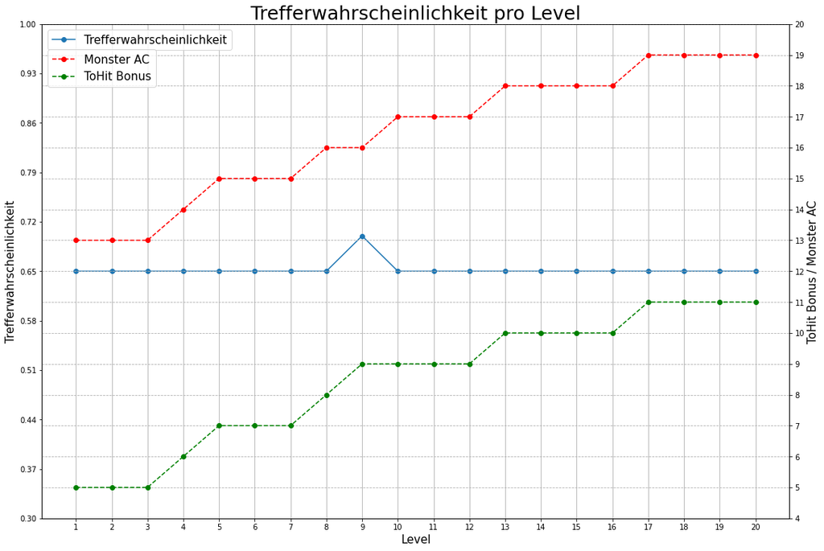

## Advantage Disadvantage Auswertung

### Veränderte Trefferwahrscheinlichkeit

Bei Advantage wirft man zwei Würfel und nimmt das bessere Ergebnis.

Die Wahrscheinlichkeit mit Advantage zu treffen ist wieder 1 minus der Wahrscheinlichkeit, dass beide Würfe nicht treffen.

Z.B. toHit: +10, AC: 13 da würde 3 und höher treffen, bzw. 2 und 1 wären ein Misserfolg:

- Es gibt insgesamt 400 (20*20) mögliche Kombinationen.
- Davon sind nur 4 ein Misserfolg:
  - (1, 1) (1, 2) (2, 1), (2, 2)
- Daher ist die Wahrscheinlichkeit eines Misserfolgs 4/400, oder 1%
- Wieder im Umkehrschluss ist ein Wurf mit +10 toHit mit Advantage gegen eine AC 13 zu 99% erfolgreich

#### Trefferwahrscheinlichkeit mit Disadvantage

Z.B. toHit: +1, AC: 20, eine 19 und 20 würden treffen: Die Berechnung folgt demselben Prinzip:

- Es gibt insgesamt 400 (20*20) mögliche Kombinationen.
- Davon sind nur 4 ein Erfolg:
  - (19, 19) (19, 20) (20, 19), (20, 20)
- Daher ist die Wahrscheinlichkeit eines Misserfolgs 396/400, oder 99%
- Im Umkehrschluss ist ein Wurf mit +1 toHit mit Disadvantage gegen eine AC 20 nur zu 1% erfolgreich

#### Formalisierung der Trefferwahrscheinlichkeit

Für einen straight roll:

- $p = 1 - \frac{AC-toHit-1}{20}$

Für einen Treffer mit Advantage:

- $p = 1 -(\frac{AC-toHit-1}{20})^2$

#### Honorable Mention: Trip-Advantage

An dieser Stelle nur erwähnt, aber in weiterer Folge ignoriert, die Möglichkeit des Dreifach-Advantage. Erreicht z.B. über den Elven Accuracy Feat, oder dem Lucky Feat (wenn er in einer Advantage Situation angewendet wird)

Berechnung wie für Advantage, nur mit 3d20 (8.000 mögliche Kombinationen) - daher:

- $p = 1- (\frac{AC-toHit-1}{20})^3$

| Benötigtes Ergebnis | Trefferwahrscheinlichkeit | mit Advantage | mit Disadvantage | Unterschied zu Base | Umrechnung statischer Bonus |
| --- | --- | --- | --- | --- | --- |
| 2 | 0.95 | 0.9975 | 0.9025 | 0.0475 | 0.95 |
| 3 | 0.90 | 0.9900 | 0.8100 | 0.0900 | 1.80 |
| 4 | 0.85 | 0.9775 | 0.7225 | 0.1275 | 2.55 |
| 5 | 0.80 | 0.9600 | 0.6400 | 0.1600 | 3.20 |
| 6 | 0.75 | 0.9375 | 0.5625 | 0.1875 | 3.75 |
| 7 | 0.70 | 0.9100 | 0.4900 | 0.2100 | 4.20 |
| 8 | 0.65 | 0.8775 | 0.4225 | 0.2275 | 4.55 |
| 9 | 0.60 | 0.8400 | 0.3600 | 0.2400 | 4.80 |
| 10 | 0.55 | 0.7975 | 0.3025 | 0.2475 | 4.95 |
| 11 | 0.50 | 0.7500 | 0.2500 | 0.2500 | 5.00 |
| 12 | 0.45 | 0.6975 | 0.2025 | 0.2475 | 4.95 |
| 13 | 0.40 | 0.6400 | 0.1600 | 0.2400 | 4.80 |
| 14 | 0.35 | 0.5775 | 0.1225 | 0.2275 | 4.55 |
| 15 | 0.30 | 0.5100 | 0.0900 | 0.2100 | 4.20 |
| 16 | 0.25 | 0.4375 | 0.0625 | 0.1875 | 3.75 |
| 17 | 0.20 | 0.3600 | 0.0400 | 0.1600 | 3.20 |
| 18 | 0.15 | 0.2775 | 0.0225 | 0.1275 | 2.55 |
| 19 | 0.10 | 0.1900 | 0.0100 | 0.0900 | 1.80 |
| 20 | 0.05 | 0.0975 | 0.0025 | 0.0475 | 0.95 |

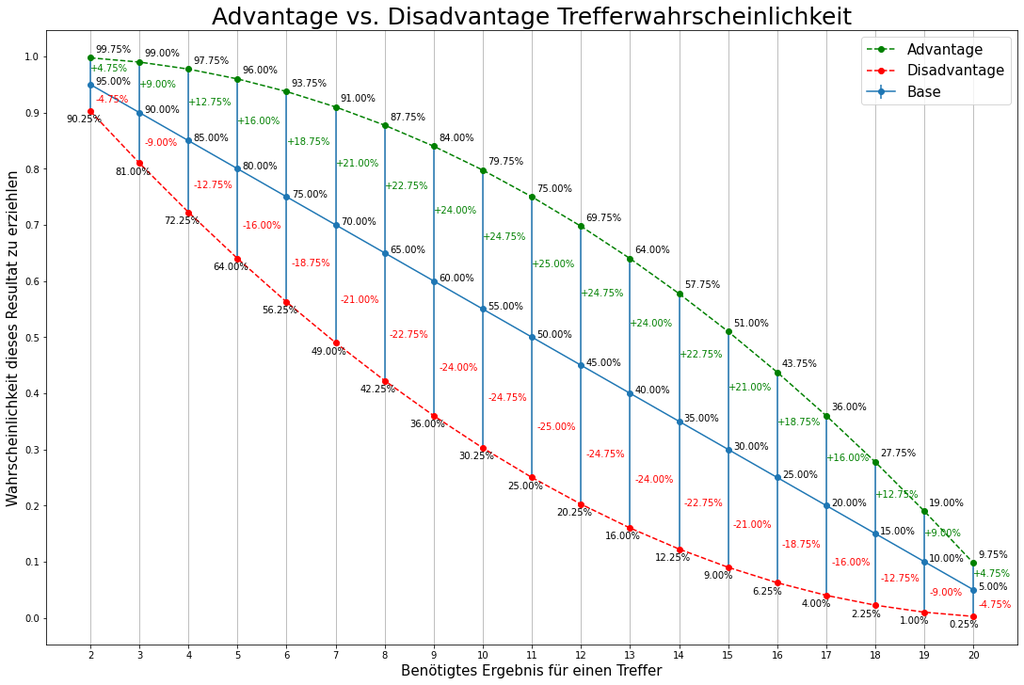

### Advantage/Disadvantage per Level

Welche Auswirkungen hat Advantage auf die Trefferwahrscheinlichkeit pro Level?

| Level | 1 | 2 | 3 | 4 | 5 | 6 | 7 | 8 | 9 | 10 | 11 | 12 | 13 | 14 | 15 | 16 | 17 | 18 | 19 | 20 |
| --- | --- | --- | --- | --- | --- | --- | --- | --- | --- | --- | --- | --- | --- | --- | --- | --- | --- | --- | --- | --- |
| Proficiency Bonus | 2.0000 | 2.0000 | 2.0000 | 2.0000 | 3.0000 | 3.0000 | 3.0000 | 3.0000 | 4.00 | 4.0000 | 4.0000 | 4.0000 | 5.0000 | 5.0000 | 5.0000 | 5.0000 | 6.0000 | 6.0000 | 6.0000 | 6.0000 |
| ToHit Bonus | 5.0000 | 5.0000 | 5.0000 | 6.0000 | 7.0000 | 7.0000 | 7.0000 | 8.0000 | 9.00 | 9.0000 | 9.0000 | 9.0000 | 10.0000 | 10.0000 | 10.0000 | 10.0000 | 11.0000 | 11.0000 | 11.0000 | 11.0000 |
| Monster AC | 13.0000 | 13.0000 | 13.0000 | 14.0000 | 15.0000 | 15.0000 | 15.0000 | 16.0000 | 16.00 | 17.0000 | 17.0000 | 17.0000 | 18.0000 | 18.0000 | 18.0000 | 18.0000 | 19.0000 | 19.0000 | 19.0000 | 19.0000 |
| Trefferwahrscheinlichkeit | 0.6500 | 0.6500 | 0.6500 | 0.6500 | 0.6500 | 0.6500 | 0.6500 | 0.6500 | 0.70 | 0.6500 | 0.6500 | 0.6500 | 0.6500 | 0.6500 | 0.6500 | 0.6500 | 0.6500 | 0.6500 | 0.6500 | 0.6500 |
| Trefferwahrscheinlichkeit mit ADV | 0.8775 | 0.8775 | 0.8775 | 0.8775 | 0.8775 | 0.8775 | 0.8775 | 0.8775 | 0.91 | 0.8775 | 0.8775 | 0.8775 | 0.8775 | 0.8775 | 0.8775 | 0.8775 | 0.8775 | 0.8775 | 0.8775 | 0.8775 |

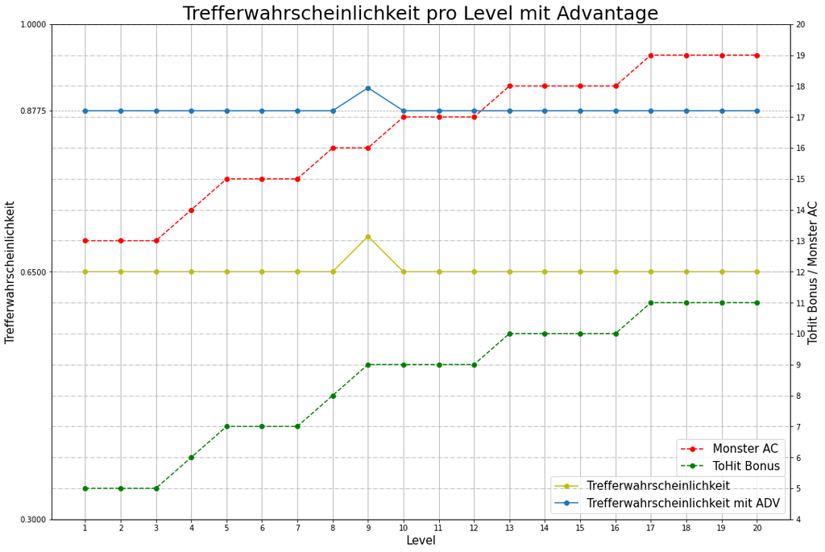

# Waffen Vergleich

Nachdem oben der Schwerpunkt auf die Trefferwahrscheinlichkeit lag, folgt hier die Analyse des zweiten Teils - des Waffenschadens.

## Welchen Unterschied macht die Wahl der Waffe?

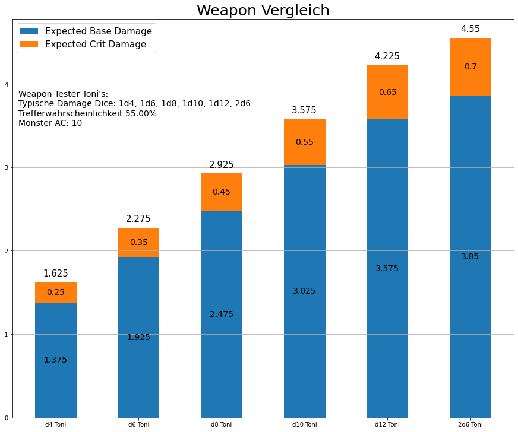

Durchschnittliche Schaden eines d4 = 2,5. Eines d6 = 3,5 ... Daher ist die Steigerung +1.

Diese Steigerung wird um die Trefferwahrscheinlichkeit modifiziert, daher steigt der Schaden um +0,55

Der Crit Schaden eines d4 = 5. Eines d6 = 7 ... Der Crit Schaden steigt um 2.

Auch hier die +2 Steigerung mal der Crit-Chance (0,05) ergibt die zu sehende Steigerung von +0,1

Zusammenaddiert ergibt sich also für jede Waffenstufe ein Plus von 0,65

Große Ausnahme ist natürlich die 2d6. Da es sich hier um keine Erhöhung im Sinne eines d14 ist, sondern eine Verdoppelung der Werte des d6.

Daher ist der Unterschied zum d12: 0,325 (+0,275 für regulär to Hit bzw. +0,05 für Crit Schaden).

Somit ist der Unterschied zwischen d12 und 2d6 genau die Hälfte vom Unterschied der anderen Waffen.

### Erwarteter Schaden per Monster AC

| Monster AC | 2 | 3 | 4 | 5 | 6 | 7 | 8 | 9 | 10 | 11 | 12 | 13 | 14 | 15 | 16 | 17 | 18 | 19 | Unterschied |
| --- | --- | --- | --- | --- | --- | --- | --- | --- | --- | --- | --- | --- | --- | --- | --- | --- | --- | --- | --- |
| d4 | 2.625 | 2.5 | 2.375 | 2.25 | 2.125 | 2.0 | 1.875 | 1.75 | 1.625 | 1.5 | 1.375 | 1.25 | 1.125 | 1.0 | 0.875 | 0.75 | 0.625 | 0.5 | -0.125 |
| d6 | 3.675 | 3.5 | 3.325 | 3.15 | 2.975 | 2.8 | 2.625 | 2.45 | 2.275 | 2.1 | 1.925 | 1.75 | 1.575 | 1.4 | 1.225 | 1.05 | 0.875 | 0.7 | -0.175 |
| d8 | 4.725 | 4.5 | 4.275 | 4.05 | 3.825 | 3.6 | 3.375 | 3.15 | 2.925 | 2.7 | 2.475 | 2.25 | 2.025 | 1.8 | 1.575 | 1.35 | 1.125 | 0.9 | -0.225 |
| d10 | 5.775 | 5.5 | 5.225 | 4.95 | 4.675 | 4.4 | 4.125 | 3.85 | 3.575 | 3.3 | 3.025 | 2.75 | 2.475 | 2.2 | 1.925 | 1.65 | 1.375 | 1.1 | -0.275 |
| d12 | 6.825 | 6.5 | 6.175 | 5.85 | 5.525 | 5.2 | 4.875 | 4.55 | 4.225 | 3.9 | 3.575 | 3.25 | 2.925 | 2.6 | 2.275 | 1.95 | 1.625 | 1.3 | -0.325 |
| 2d6 | 7.35 | 7.0 | 6.65 | 6.3 | 5.95 | 5.6 | 5.25 | 4.9 | 4.55 | 4.2 | 3.85 | 3.5 | 3.15 | 2.8 | 2.45 | 2.1 | 1.75 | 1.4 | -0.35 |

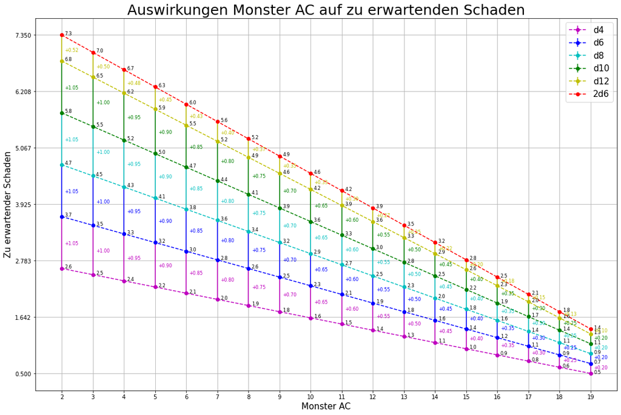

Man sieht, dass die Abstände der Waffenwahl abnehmen. Bei einer hohen Trefferwahrscheinlichkeit macht es einen großen Unterschied welche Waffe man verwendet.

Hingegen ist bei einer geringen Trefferwahrscheinlichkeit der Schadensoutput weniger relevant.

Vulgo: Es ist egal mit welcher Waffe ich nicht treffe.

Natürlich sind auch hier die Unterschiede zwischen den Waffenarten gleich - mit Ausnahme d12 vs. 2d6 (s.o.).

## ASI Auswirkungen

Welchen Unterschied macht eine Erhöhung eines Attributes auf den Schaden.

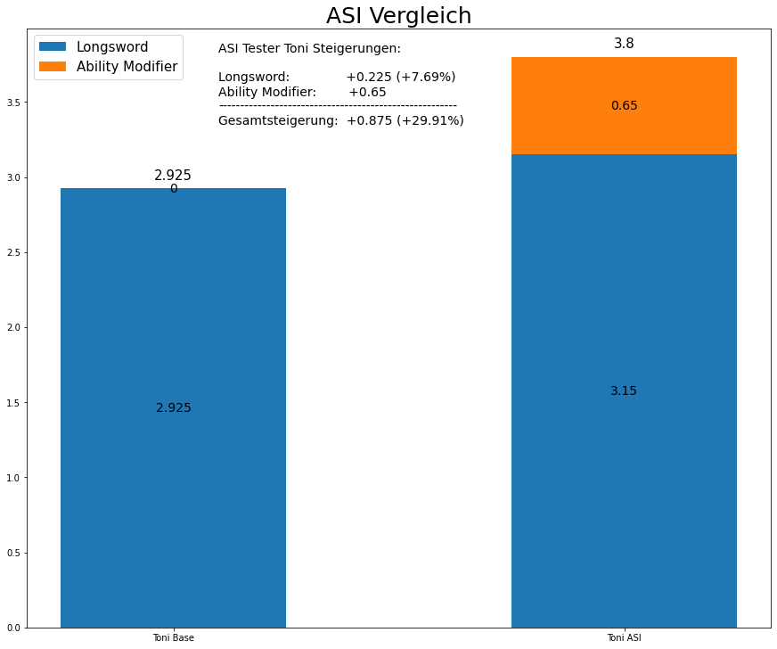

# Was ist besser? Ein +2 Schwert, oder Flame Tongue Sword

Zum Vergleich stehen:

- Ein Flame Tongue Longsword mit zusätzlichen 2d6 fire damage
- Ein +2 Longsword

## Punkte zu bedenken

- Beide werden vom Spiel als "rare" eingestuft.
- 2d6 fire Damage sind im Schnitt 7 Punkte Damage
- Das +2 Schwert hat "nur" +2 - aber auch ein +2 auf to Hit
  - Kann das +2 to Hit für den Unterschied im Damage ausmachen?

```
Helden Name: Toni Plus2
ToHit-Bonus: +2
Trefferwahrscheinlichkeit: 0.65
Zu erwartender Schaden: 6.88
--------------------
Helden Name: Toni Flame Tongue
ToHit-Bonus: +0
Trefferwahrscheinlichkeit: 0.55
Zu erwartender Schaden: 9.28
```

## Zwischenfazit

Man sieht also einen deutlichen Unterschied von 2,4 Punkten bei einer durchschnittlichen Trefferwahrscheinlichkeit.

Aber wir haben noch nicht die erhöhte Trefferwahrscheinlichkeit überprüft.

Existiert ein Punkt, bei dem sich der Bonus auf toHit auszahlt?

## Zu erwartender Schaden nach AC

| Monster AC | 2 | 3 | 4 | 5 | 6 | 7 | 8 | 9 | 10 | 11 | ... | 13 | 14 | 15 | 16 | 17 | 18 | 19 | 20 | 21 | 22 |
| --- | --- | --- | --- | --- | --- | --- | --- | --- | --- | --- | --- | --- | --- | --- | --- | --- | --- | --- | --- | --- | --- |
| Flame Tongue | 15.075 | 14.35 | 13.625 | 12.9 | 12.175 | 11.45 | 10.725 | 10.0 | 9.275 | 8.55 | ... | 7.1 | 6.375 | 5.65 | 4.925 | 4.2 | 3.475 | 2.75 | 1.3 | 1.3 | 1.3 |
| +2 Sword | 9.725 | 9.725 | 9.725 | 9.25 | 8.775 | 8.3 | 7.825 | 7.35 | 6.875 | 6.4 | ... | 5.45 | 4.975 | 4.5 | 4.025 | 3.55 | 3.075 | 2.6 | 2.125 | 1.65 | 0.7 |
| Unterschied | 5.35 | 4.625 | 3.9 | 3.65 | 3.4 | 3.15 | 2.9 | 2.65 | 2.4 | 2.15 | ... | 1.65 | 1.4 | 1.15 | 0.9 | 0.65 | 0.4 | 0.15 | -0.825 | -0.35 | 0.6 |

3 rows × 21 columns

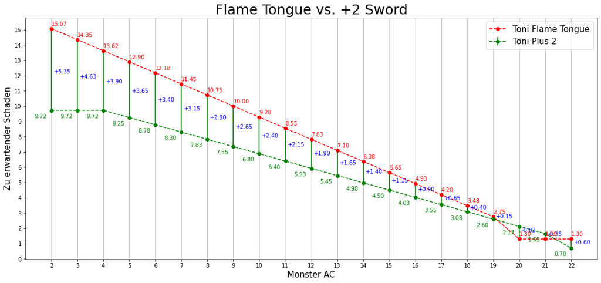

# Analyse der Fighting Styles

## Archery

You gain a +2 bonus to attack rolls you make with ranged weapons.

```
Helden Name: Toni Archer
ToHit-Bonus: +2
Trefferwahrscheinlichkeit: 0.65
Zu erwartender Schaden: 4.78
----------
Detailaufschlüsselung:
  * Longbow
      Zu erwartender Schaden: 3.375000000000001
      Base Damage: 4.5
      Crit Damage: 9.0
  * Ability Modifier
      Zu erwartender Schaden: 1.4000000000000001
      Base Damage: 2
      Crit Damage: 2
```

## Dueling

When you are wielding a melee weapon in one hand and no other weapons, you gain a +2 bonus to damage rolls with that weapon.

```
Helden Name: Toni Duelist
ToHit-Bonus: +0
Trefferwahrscheinlichkeit: 0.55
Zu erwartender Schaden: 5.33
----------
Detailaufschlüsselung:
  * Longsword
      Zu erwartender Schaden: 2.9250000000000007
      Base Damage: 4.5
      Crit Damage: 9.0
  * Dueling FS
      Zu erwartender Schaden: 1.2000000000000002
      Base Damage: 2
      Crit Damage: 2
  * Ability Modifier
      Zu erwartender Schaden: 1.2000000000000002
      Base Damage: 2
      Crit Damage: 2
```

## Great Weapon Fighting

When you roll a 1 or 2 on a damage die for an attack you make with a melee weapon that you are wielding with two hands, you can reroll the die and must use the new roll, even if the new roll is a 1 or a 2. The weapon must have the two-handed or versatile property for you to gain this benefit.

Die Idee des GWF ist, dass bei einer 1, oder 2 dieses Ergebnis mit einem neuen Wurf ersetzt wird.

- Unser Standard Array für einen d6 ist [1,2,3,4,5,6] = Durchschnitt = 3,5
- Wird bei einem GWF 1, oder 2 mit einem anderen Wurf ersetzt, wird 1, oder 2 mit dem durchschnitt des neuen Wurfs ersetzt
- Daher ist das angepasste Array: [3.5,3.5,3,4,5,6], Durchschnitt = 4,1667

```
Helden Name: Toni Great Weapon
ToHit-Bonus: +0
Trefferwahrscheinlichkeit: 0.55
Zu erwartender Schaden: 6.62
----------
Detailaufschlüsselung:
  * Greatsword
      Zu erwartender Schaden: 5.416666666666668
      Base Damage: 8.333333333333334
      Crit Damage: 16.666666666666668
  * Ability Modifier
      Zu erwartender Schaden: 1.2000000000000002
      Base Damage: 2
      Crit Damage: 2
```

## Two-Weapon Fighting

When you engage in two-weapon fighting, you can add your ability modifier to the damage of the second attack.

```
Helden Name: Toni Double Sword
ToHit-Bonus: +0
Trefferwahrscheinlichkeit: 0.55
Zu erwartender Schaden: 6.95
----------
Detailaufschlüsselung:
  * Shortsword
      Zu erwartender Schaden: 2.2750000000000004
      Base Damage: 3.5
      Crit Damage: 7.0
  * Ability Modifier
      Zu erwartender Schaden: 1.2000000000000002
      Base Damage: 2
      Crit Damage: 2
  * Shortsword_offHand
      Zu erwartender Schaden: 2.2750000000000004
      Base Damage: 3.5
      Crit Damage: 7.0
  * Ability Modifier_offHand
      Zu erwartender Schaden: 1.2000000000000002
      Base Damage: 2
      Crit Damage: 2
```

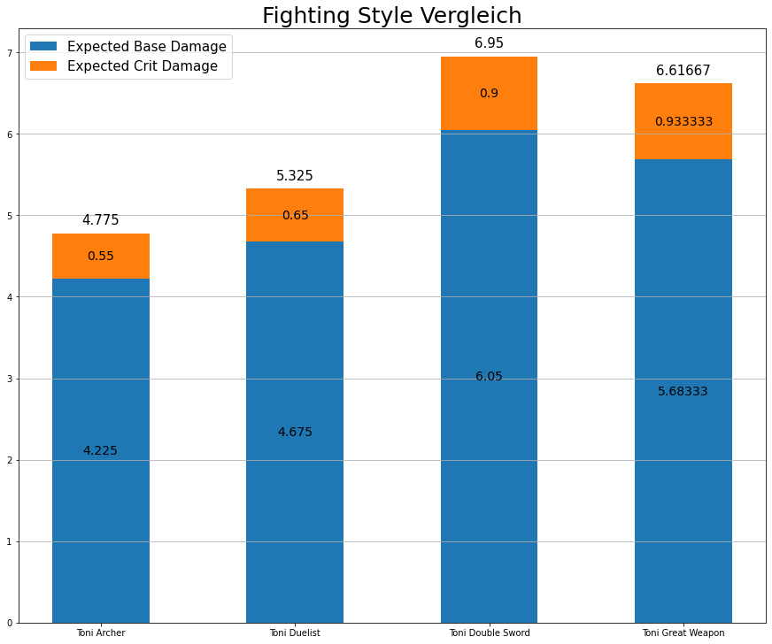

# Improved Critical (Fighter) vs. Brutal Critical (Barbarian)

## Fighter Champion Subclass

- Improved Critical
  - "Beginning when you choose this archetype at 3rd level, your weapon attacks score a critical hit on a roll of 19 or 20."
- Superior Critical
  - Starting at 15th level, your weapon attacks score a critical hit on a roll of 18-20.

vgl. PHB S. 72

## Barbarian Brutal Critical

- "Beginning at 9th level, you can roll one additional weapon damage die when determining the extra damage for a critical hit with a melee attack. This increases to two additional dice at 13th level and three additional dice at 17th level."

vgl. PHB S. 46

# Links zum Weiterlesen

https://medium.com/@aking11/how-advantageous-is-advantage-in-d-d-5e-b0be28cb56a7